# distributions.R

h0540352

Thu Aug 06 15:03:15 2015

```r
library(lmom)
```

# TODO

4. Reversieren einer Verteilung veranschaulichen

# Weibullverteilung

linksseitig begrenzt

## 1) stats::Weibull

- a > 0 is the shape parameter
- b > 0 is the scale parameter

cdf: $F(x) = 1 - e^{- \left(\frac{x}{scale}\right)^{shape}} = 1 - e^{- (x/b)^a}$ für $x > 0$

pdf: $f(x) = \frac{a}{b} \left(\frac{x}{b}\right)^{(a-1)} e^{- (x/b)^a}$

`lower.tail = TRUE` per default: also für Minima parametrisiert

## 2) Wikipedia

ident zur stats:Weibull parametrisiert

https://en.wikipedia.org/wiki/Weibull_distribution

- k > 0 is the shape parameter
- λ > 0 is the scale parameter

pdf: $f(x;\lambda,k) = \frac{k}{\lambda}\left(\frac{x}{\lambda}\right)^{k-1}e^{-(x/\lambda)^{k}}$

cdf: $F(x;k,\lambda) = 1 - e^{-\left(\frac{x}{scale}\right)^{shape}} = 1 - e^{-(x/\lambda)^k}$

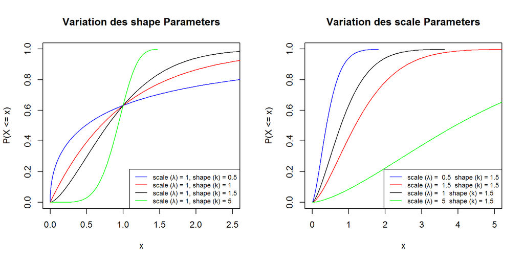

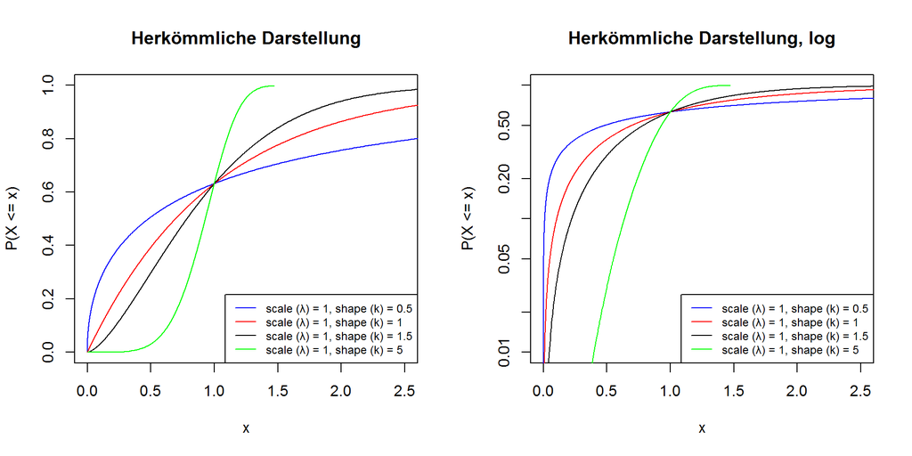

[figure not shown]

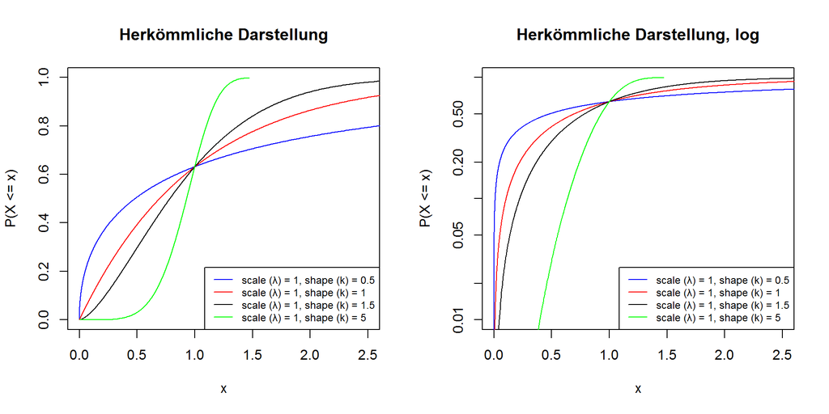

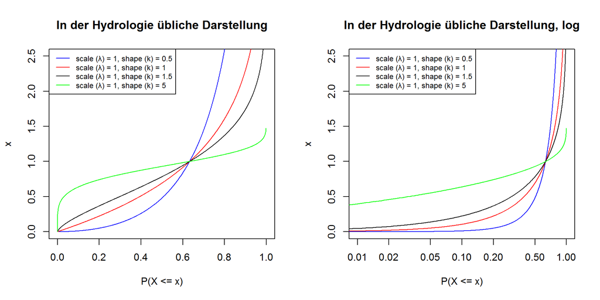

## 3) lmom::quawei

- location parameter zeta
- scale parameter beta
- shape parameter delta

cdf: $F(x) = 1 - e^{ - \left( \frac{x - location} {scale} \right)^{shape} } = 1 - e^{ - \left( \frac{x - \zeta} {\beta} \right)^\delta }$

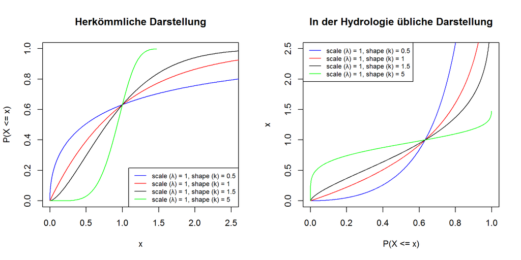

# GEV

## 1) evd::gev

- $\mu \in \mathbf{R}$ is the location parameter
- $\sigma > 0$ is the scale parameter
- $\xi \in \mathbf{R}$ is the shape parameter

cdf: $F(x;\mu,\sigma,\xi) = \exp\left\{-\left[1+\xi\left(\frac{x-\mu}{\sigma}\right)\right]^{-1/\xi}\right\}$

für $\xi\to 0$ $F(x;\mu,\sigma,0) = \exp\left\{-\exp \left(-\frac{x-\mu}{\sigma}\right)\right\}$

Support $x \in \left[ \mu − \sigma / \xi, + \infty\right)$ für $\xi > 0$

$x \in (−\infty, +\infty)$ für $\xi = 0$

$x \in (−\infty, \mu − \sigma / \xi ]$ für $\xi < 0$

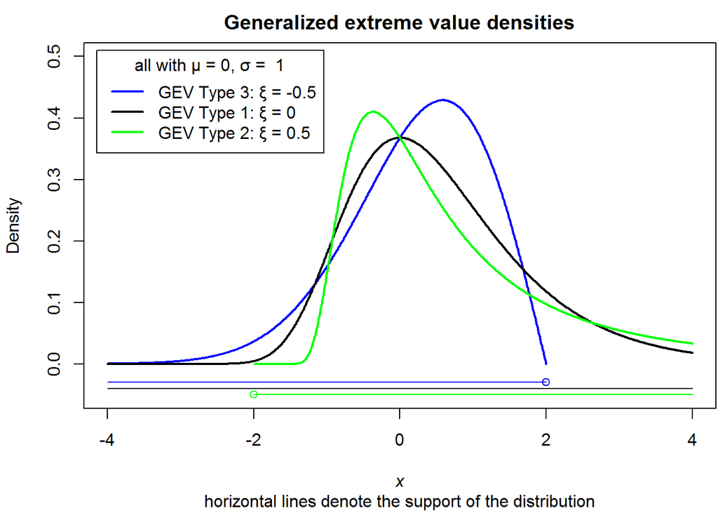

```r
library(evd)

pgev <- function(q, loc = 0, scale = 1, shape = 0){
  t1 <- if(shape == 0) {
    exp(-(q - loc)/scale)
  } else {
    (1 + shape * (q - loc)/scale )^(-1/shape)
  }

  p <- exp(-t1)

  # setting desity to NA outside of range
  outside <- numeric()
  if(shape < 0) outside <- q > loc - scale/shape
  if(shape > 0) outside <- q < loc - scale/shape
  p[outside] <- NA

  return(p)
}

dgev <- function(x, loc = 0, scale = 1, shape = 0){
  t1 <- if(shape == 0) {
    exp(-(x - loc)/scale)
  } else {
    (1 + shape * (x - loc)/scale )^(-1/shape)
  }

  d <- 1/scale * t1^(shape + 1) * exp(-t1)

  # setting desity to NA outside of range
  outside <- numeric()
  if(shape < 0) outside <- x > loc - scale/shape
  if(shape > 0) outside <- x < loc - scale/shape
  d[outside] <- NA

  return(d)
}

draw_support <- function(y, loc = 0, scale = 1, shape = 0, ...) {
  if (shape == 0) segments(x0 = par("xaxp")[1], x1 = par("xaxp")[2], y0 = y, ...)

  end <- loc - scale/shape
  if (shape < 0) segments(x0 = par("xaxp")[1], x1 = end, y0 = y, ...)
  if (shape > 0) segments(x0 = end, x1 = par("xaxp")[2], y0 = y, ...)
  points(x = end, y = y, pch = 21, ...)
}


x <- seq(-4, 4, 0.01)
shape <- c("3" = -0.5, "1" = 0, "2" = 0.5)

col <- c("blue", "black", "green")
prob <- seq(0, 1, 0.001)


par(mar = c(5, 4, 2, 0) + 0.1)
plot(NA, xlim=range(x), ylim=c(-0.05, 0.5), type = "n",
     xlab = expression(italic(x)), ylab = "Density",
     main = "Generalized extreme value densities",
     sub = "horizontal lines denote the support of the distribution")

for(i in seq_along(shape)) {
  lines(x, dgev(x, shape = shape[i]), col=col[i], lwd = 2)
  draw_support(shape = shape[i], col=col[i], y = -i/100 -0.02 )
}

legend("topleft", lwd = 2, col = col, inset = 0.02,
       title = "all with \u03bc = 0, \u03c3 =  1",
       legend = paste0("GEV Type ", names(shape), ": \u03be = ", shape))
```

## 2) Weibull als Spezialfall der GEV ($\xi < 0$)

- $\mu \in \mathbf{R}$ is the location parameter
- $\sigma > 0$ is the scale parameter

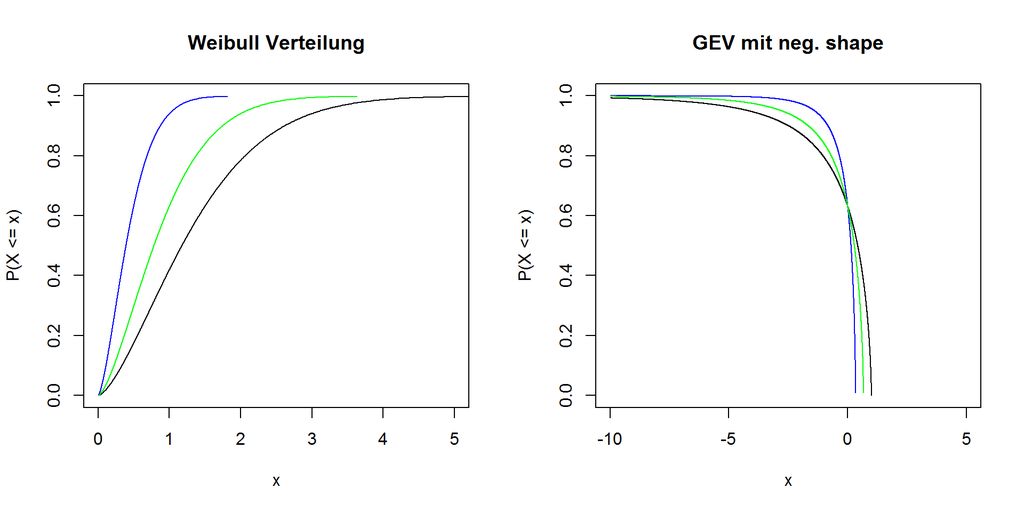

https://en.wikipedia.org/wiki/Fr%C3%A9chet_distribution https://en.wikipedia.org/wiki/Weibull_distribution https://en.wikipedia.org/wiki/Cumulative_frequency_analysis https://en.wikipedia.org/wiki/CumFreq#cite_ref-Ritz_1-0 https://en.wikipedia.org/wiki/Distribution_fitting#Inverting_skewness https://en.wikipedia.org/wiki/File:Gumbel_distribution_and_Gumbel_mirrored.png